# Career Consultation and Prediciting Data Science Compensation

Ariella Rose, Benjamin Lewis, Rahul Jain, Yoshitomo Okada

4/25/2021

## Introduction

### Welcome to Twerk From Home

Twerk From Home is a Career Consulting Company that helps clients take the next steps towards a successful career. We do the career planning, while you *Twerk From Home!*

A huge factor in deciding one’s next career move is compensation. In this report, we target clients who want to transition into, or continue, a career in Data Science. We highlight the factors that enable data professionals to make above average salaries, greater than **$ 64,750.60**, using the data set, “How much does data scientists earn in 2017-2020,” obtained from Stack overflow. We begin by running a logistic regression model to ascertain which variables are significant in increasing someone’s likelihood of making an above average salary, and use this information to inform our clients on what decisions they should make to ensure they reach their salary goal. Afterwards, we employ several other predictive models to improve predictive power and accuracy.

Finally, we end with some discussion about our analysis and give recommendations to our clients based on our output on how to secure a high paying data science position.

## Load and Clean Data

```r
#Read Data
dssalaries <- read.csv("processed_data_toDummies.csv")
nrow(dssalaries)
```

```
## [1] 33601
```

```r
str(dssalaries)
```

```
## 'data.frame':    33601 obs. of  14 variables:
##  $ Year                                         : int  2017 2017 2017 2017 2017 2017 2017 2017 2017 2017 ...
##  $ Hobbyist                                     : chr  "Yes, both" "Yes, I program as a hobby" "No" "Yes, I program as a hobby" ...
##  $ ConvertedComp                                : num  43750 51282 25000 100000 27000 ...
##  $ Country                                      : chr  "United Kingdom" "Denmark" "Israel" "United States" ...
##  $ EdLevel                                      : chr  "Bachelor's degree" "Some college/university study without earning a bachelor's degree" "Some college/university study without earning a bachelor's degree" "Some college/university study without earning a bachelor's degree" ...
##  $ Employment                                   : chr  "Employed full-time" "Employed part-time" "Employed full-time" "Employed full-time" ...
##  $ JobSat                                       : int  4 10 6 5 7 10 4 8 10 10 ...
##  $ OrgSize                                      : chr  "2 to 9 employees" "100 to 499 employees" "5,000 to 9,999 employees" "20 to 99 employees" ...
##  $ UndergradMajor                               : chr  "Computer science" "Computer science" "Computer science" "Computer science" ...
##  $ YearsCodePro                                 : int  2 3 4 15 5 5 10 9 1 16 ...
##  $ Data.scientist.or.machine.learning.specialist: int  1 1 1 0 0 0 0 0 0 0 ...
##  $ Database.administrator                       : int  1 0 0 1 1 1 1 1 1 1 ...
##  $ Data.or.business.analyst                     : int  NA NA NA NA NA NA NA NA NA NA ...
##  $ Engineer..data                               : int  NA NA NA NA NA NA NA NA NA NA ...
```

```r
summary(dssalaries)
```

```
##       Year        Hobbyist         ConvertedComp         Country
##  Min.   :2017   Length:33601       Min.   :     0.18   Length:33601
##  1st Qu.:2018   Class :character   1st Qu.: 24576.00   Class :character
##  Median :2019   Mode  :character   Median : 53000.00   Mode  :character
##  Mean   :2019                      Mean   : 62593.09
##  3rd Qu.:2019                      3rd Qu.: 87036.00
##  Max.   :2020                      Max.   :299436.00
##
##    EdLevel           Employment            JobSat         OrgSize
##  Length:33601       Length:33601       Min.   : 0.000   Length:33601
##  Class :character   Class :character   1st Qu.: 5.000   Class :character
##  Mode  :character   Mode  :character   Median : 6.000   Mode  :character
##                                        Mean   : 6.124
##                                        3rd Qu.: 8.000
##                                        Max.   :10.000
##                                        NA's   :75
##  UndergradMajor      YearsCodePro
##  Length:33601       Min.   : 1.000
##  Class :character   1st Qu.: 3.000
##  Mode  :character   Median : 6.000
##                     Mean   : 8.756
##                     3rd Qu.:12.000
##                     Max.   :30.000
##                     NA's   :83
##  Data.scientist.or.machine.learning.specialist Database.administrator
##  Min.   :0.0000                                Min.   :0.0000
##  1st Qu.:0.0000                                1st Qu.:0.0000
##  Median :0.0000                                Median :1.0000
##  Mean   :0.3217                                Mean   :0.5401
##  3rd Qu.:1.0000                                3rd Qu.:1.0000
##  Max.   :1.0000                                Max.   :1.0000
##
##  Data.or.business.analyst Engineer..data
##  Min.   :0.0000           Min.   :0.000
##  1st Qu.:0.0000           1st Qu.:0.000
##  Median :0.0000           Median :0.000
##  Mean   :0.3215           Mean   :0.304
##  3rd Qu.:1.0000           3rd Qu.:1.000
##  Max.   :1.0000           Max.   :1.000
##  NA's   :2564             NA's   :13355
```

```r
#Convert Year to Factor
dssalaries$Year <- as.factor(dssalaries$Year)

#Convert Hobbyist to Factor
dssalaries$Hobbyist <- as.factor(dssalaries$Hobbyist)

#Combine all Hobbyist Yes answers to a single factor, leaving two factors for Hobbyist: Yes and No
levels(dssalaries$Hobbyist) <- c("No","Yes","Yes","Yes","Yes")

#Convert country to factor
dssalaries$Country <- as.factor(dssalaries$Country)

#Convert EdLevel to factor
dssalaries$EdLevel <- as.factor(dssalaries$EdLevel)

#Remove all rows missing EdLevel
dssalaries <- droplevels(dssalaries[!dssalaries$EdLevel=='',])

#Convert Employment to factor
dssalaries$Employment <- as.factor(dssalaries$Employment)

#Remove all rows missing Employment
dssalaries <- droplevels(dssalaries[!dssalaries$Employment=='',])

#Replace JobSat NA's with the mean
dssalaries$JobSat <- ifelse(is.na(dssalaries$JobSat),mean(dssalaries$JobSat,na.rm=TRUE),dssalaries$JobSat)

#Convert OrgSize to factor
dssalaries$OrgSize <- as.factor(dssalaries$OrgSize)

#Remove all rows missing OrgSize
dssalaries <- droplevels(dssalaries[!dssalaries$OrgSize=='',])
dssalaries <- droplevels(dssalaries[!dssalaries$OrgSize=='I prefer not to answer',])
dssalaries <- droplevels(dssalaries[!dssalaries$OrgSize=="I don't know",])

#Convert UndergradMajor to factor
dssalaries$UndergradMajor <- as.factor(dssalaries$UndergradMajor)

#Remove all rows missing UndergradMajor
dssalaries <- droplevels(dssalaries[!dssalaries$UndergradMajor=='',])

#Replace YearsCodePro NA's with the mean
dssalaries$YearsCodePro <- ifelse(is.na(dssalaries$YearsCodePro),mean(dssalaries$YearsCodePro,na.rm=TRUE),dssalaries$YearsCodePro)

#Remove all rows with any remaining NA values
dssalaries <- dssalaries[complete.cases(dssalaries),]

#Remove Years that no longer have any data points
dssalaries <- droplevels(dssalaries[!dssalaries$Year=='2017',])
dssalaries <- droplevels(dssalaries[!dssalaries$Year=='2018',])

#Create new column for salary above mean
dssalaries$salaryabove <- ifelse(dssalaries$ConvertedComp > mean(dssalaries$ConvertedComp),1,0)

#Combine some of the EdLevel factors, grouping Masters and below as "Basic"
levels(dssalaries$EdLevel) <- c("Basic","Basic","Doctorate","Basic","Professionl","Basic")

#Combine some of the Employment factors, leaving 2 factor for Employment: Full-time and Part-time
levels(dssalaries$Employment) <- c("Full","Part","Full")

#Combine some of the OrgSize factors, simplifying to 0-500, 50-10K, and 10k+
levels(dssalaries$OrgSize) <- c("500-10K","0-500","10K+","0-500","0-500","0-500","500-10K","500-10K","0-500")

# Remove uneeded variables, ConvertedComp used as salaryabove and Country has too many factors to be useful
dssalaries$ConvertedComp <- NULL
dssalaries$Country <- NULL
```

## Getting Data Ready for Analysis

```r
#Convert all variables to dummies
dssalaries_m <- as.data.frame(model.matrix(~.-1,dssalaries))
str(dssalaries_m)
```

```
## 'data.frame':    18043 obs. of  26 variables:
##  $ Year2019                                     : num  1 1 1 1 1 1 1 1 1 1 ...
##  $ Year2020                                     : num  0 0 0 0 0 0 0 0 0 0 ...
##  $ HobbyistYes                                  : num  1 1 1 0 0 1 1 1 1 1 ...
##  $ EdLevelDoctorate                             : num  0 0 0 0 0 0 0 0 0 0 ...
##  $ EdLevelProfessionl                           : num  0 0 0 0 0 0 0 0 0 0 ...
##  $ EmploymentPart                               : num  0 0 0 0 0 0 0 0 0 0 ...
##  $ JobSat                                       : num  6 8 8 4 8 8 8 4 8 5 ...
##  $ OrgSize0-500                                 : num  1 1 0 0 0 1 1 0 1 1 ...
##  $ OrgSize10K+                                  : num  0 0 0 0 1 0 0 1 0 0 ...
##  $ UndergradMajorBusiness                       : num  0 0 0 0 0 0 0 0 0 0 ...
##  $ UndergradMajorComputer science               : num  1 1 1 0 0 1 1 1 1 0 ...
##  $ UndergradMajorFine arts or performing arts   : num  0 0 0 0 0 0 0 0 0 0 ...
##  $ UndergradMajorHealth science                 : num  0 0 0 0 0 0 0 0 0 0 ...
##  $ UndergradMajorHumanities                     : num  0 0 0 0 0 0 0 0 0 0 ...
##  $ UndergradMajorI never declared a major       : num  0 0 0 0 0 0 0 0 0 0 ...
##  $ UndergradMajorInformation systems            : num  0 0 0 1 0 0 0 0 0 0 ...
##  $ UndergradMajorMathematics or statistics      : num  0 0 0 0 0 0 0 0 0 0 ...
##  $ UndergradMajorNatural science                : num  0 0 0 0 1 0 0 0 0 0 ...
##  $ UndergradMajorSocial science                 : num  0 0 0 0 0 0 0 0 0 0 ...
##  $ UndergradMajorWeb development or web design  : num  0 0 0 0 0 0 0 0 0 1 ...
##  $ YearsCodePro                                 : num  4 8 3 4 3 22 23 2 8 13 ...
##  $ Data.scientist.or.machine.learning.specialist: num  0 0 0 0 1 0 0 0 0 0 ...
##  $ Database.administrator                       : num  1 1 0 1 0 0 1 0 1 1 ...
##  $ Data.or.business.analyst                     : num  0 1 1 0 0 0 0 0 0 1 ...
##  $ Engineer..data                               : num  0 1 0 0 0 1 0 1 0 0 ...
##  $ salaryabove                                  : num  1 1 0 0 0 0 1 0 0 0 ...
```

```r
summary(dssalaries_m)
```

```
##     Year2019         Year2020       HobbyistYes     EdLevelDoctorate
##  Min.   :0.0000   Min.   :0.0000   Min.   :0.0000   Min.   :0.00000
##  1st Qu.:0.0000   1st Qu.:0.0000   1st Qu.:1.0000   1st Qu.:0.00000
##  Median :1.0000   Median :0.0000   Median :1.0000   Median :0.00000
##  Mean   :0.6093   Mean   :0.3907   Mean   :0.7986   Mean   :0.06224
##  3rd Qu.:1.0000   3rd Qu.:1.0000   3rd Qu.:1.0000   3rd Qu.:0.00000
##  Max.   :1.0000   Max.   :1.0000   Max.   :1.0000   Max.   :1.00000
##  EdLevelProfessionl EmploymentPart        JobSat      OrgSize0-500
##  Min.   :0.00000    Min.   :0.00000   Min.   :2.00   Min.   :0.0000
##  1st Qu.:0.00000    1st Qu.:0.00000   1st Qu.:5.00   1st Qu.:0.0000
##  Median :0.00000    Median :0.00000   Median :6.00   Median :1.0000
##  Mean   :0.01707    Mean   :0.03497   Mean   :5.96   Mean   :0.6427
##  3rd Qu.:0.00000    3rd Qu.:0.00000   3rd Qu.:8.00   3rd Qu.:1.0000
##  Max.   :1.00000    Max.   :1.00000   Max.   :8.00   Max.   :1.0000
##   OrgSize10K+     UndergradMajorBusiness UndergradMajorComputer science
##  Min.   :0.0000   Min.   :0.00000        Min.   :0.0000
##  1st Qu.:0.0000   1st Qu.:0.00000        1st Qu.:0.0000
##  Median :0.0000   Median :0.00000        Median :1.0000
##  Mean   :0.1427   Mean   :0.03364        Mean   :0.5623
##  3rd Qu.:0.0000   3rd Qu.:0.00000        3rd Qu.:1.0000
##  Max.   :1.0000   Max.   :1.00000        Max.   :1.0000
##  UndergradMajorFine arts or performing arts UndergradMajorHealth science
##  Min.   :0.00000                            Min.   :0.000000
##  1st Qu.:0.00000                            1st Qu.:0.000000
##  Median :0.00000                            Median :0.000000
##  Mean   :0.01064                            Mean   :0.004157
##  3rd Qu.:0.00000                            3rd Qu.:0.000000
##  Max.   :1.00000                            Max.   :1.000000
##  UndergradMajorHumanities UndergradMajorI never declared a major
##  Min.   :0.00000          Min.   :0.000000
##  1st Qu.:0.00000          1st Qu.:0.000000
##  Median :0.00000          Median :0.000000
##  Mean   :0.01984          Mean   :0.009366
##  3rd Qu.:0.00000          3rd Qu.:0.000000
##  Max.   :1.00000          Max.   :1.000000
##  UndergradMajorInformation systems UndergradMajorMathematics or statistics
##  Min.   :0.00000                   Min.   :0.00000
##  1st Qu.:0.00000                   1st Qu.:0.00000
##  Median :0.00000                   Median :0.00000
##  Mean   :0.07554                   Mean   :0.06584
```

[output cut: 15 more lines]

```
##  Max.   :1.00000                             Max.   :30.00
##  Data.scientist.or.machine.learning.specialist Database.administrator
##  Min.   :0.0000                                Min.   :0.0000
##  1st Qu.:0.0000                                1st Qu.:0.0000
##  Median :0.0000                                Median :0.0000
##  Mean   :0.3231                                Mean   :0.4708
##  3rd Qu.:1.0000                                3rd Qu.:1.0000
##  Max.   :1.0000                                Max.   :1.0000
##  Data.or.business.analyst Engineer..data    salaryabove
##  Min.   :0.0000           Min.   :0.0000   Min.   :0.0000
##  1st Qu.:0.0000           1st Qu.:0.0000   1st Qu.:0.0000
##  Median :0.0000           Median :0.0000   Median :0.0000
##  Mean   :0.3103           Mean   :0.3117   Mean   :0.4189
##  3rd Qu.:1.0000           3rd Qu.:1.0000   3rd Qu.:1.0000
##  Max.   :1.0000           Max.   :1.0000   Max.   :1.0000
```

```r
#Normalize function
normalize <- function(x) {
  return ((x - min(x)) / (max(x) - min(x)))
}

# Normalize data
dssalaries_norm <- as.data.frame(lapply(dssalaries_m, normalize))
summary(dssalaries_norm)
```

```
##     Year2019         Year2020       HobbyistYes     EdLevelDoctorate
##  Min.   :0.0000   Min.   :0.0000   Min.   :0.0000   Min.   :0.00000
##  1st Qu.:0.0000   1st Qu.:0.0000   1st Qu.:1.0000   1st Qu.:0.00000
##  Median :1.0000   Median :0.0000   Median :1.0000   Median :0.00000
##  Mean   :0.6093   Mean   :0.3907   Mean   :0.7986   Mean   :0.06224
##  3rd Qu.:1.0000   3rd Qu.:1.0000   3rd Qu.:1.0000   3rd Qu.:0.00000
##  Max.   :1.0000   Max.   :1.0000   Max.   :1.0000   Max.   :1.00000
##  EdLevelProfessionl EmploymentPart        JobSat        OrgSize0.500
##  Min.   :0.00000    Min.   :0.00000   Min.   :0.0000   Min.   :0.0000
##  1st Qu.:0.00000    1st Qu.:0.00000   1st Qu.:0.5000   1st Qu.:0.0000
##  Median :0.00000    Median :0.00000   Median :0.6667   Median :1.0000
##  Mean   :0.01707    Mean   :0.03497   Mean   :0.6600   Mean   :0.6427
##  3rd Qu.:0.00000    3rd Qu.:0.00000   3rd Qu.:1.0000   3rd Qu.:1.0000
##  Max.   :1.00000    Max.   :1.00000   Max.   :1.0000   Max.   :1.0000
##   OrgSize10K.     UndergradMajorBusiness UndergradMajorComputer.science
##  Min.   :0.0000   Min.   :0.00000        Min.   :0.0000
##  1st Qu.:0.0000   1st Qu.:0.00000        1st Qu.:0.0000
##  Median :0.0000   Median :0.00000        Median :1.0000
##  Mean   :0.1427   Mean   :0.03364        Mean   :0.5623
##  3rd Qu.:0.0000   3rd Qu.:0.00000        3rd Qu.:1.0000
##  Max.   :1.0000   Max.   :1.00000        Max.   :1.0000
##  UndergradMajorFine.arts.or.performing.arts UndergradMajorHealth.science
##  Min.   :0.00000                            Min.   :0.000000
##  1st Qu.:0.00000                            1st Qu.:0.000000
##  Median :0.00000                            Median :0.000000
##  Mean   :0.01064                            Mean   :0.004157
##  3rd Qu.:0.00000                            3rd Qu.:0.000000
##  Max.   :1.00000                            Max.   :1.000000
##  UndergradMajorHumanities UndergradMajorI.never.declared.a.major
##  Min.   :0.00000          Min.   :0.000000
##  1st Qu.:0.00000          1st Qu.:0.000000
##  Median :0.00000          Median :0.000000
##  Mean   :0.01984          Mean   :0.009366
##  3rd Qu.:0.00000          3rd Qu.:0.000000
##  Max.   :1.00000          Max.   :1.000000
##  UndergradMajorInformation.systems UndergradMajorMathematics.or.statistics
##  Min.   :0.00000                   Min.   :0.00000
##  1st Qu.:0.00000                   1st Qu.:0.00000
##  Median :0.00000                   Median :0.00000
##  Mean   :0.07554                   Mean   :0.06584
```

[output cut: 15 more lines]

```
##  Max.   :1.00000                             Max.   :1.00000
##  Data.scientist.or.machine.learning.specialist Database.administrator
##  Min.   :0.0000                                Min.   :0.0000
##  1st Qu.:0.0000                                1st Qu.:0.0000
##  Median :0.0000                                Median :0.0000
##  Mean   :0.3231                                Mean   :0.4708
##  3rd Qu.:1.0000                                3rd Qu.:1.0000
##  Max.   :1.0000                                Max.   :1.0000
##  Data.or.business.analyst Engineer..data    salaryabove
##  Min.   :0.0000           Min.   :0.0000   Min.   :0.0000
##  1st Qu.:0.0000           1st Qu.:0.0000   1st Qu.:0.0000
##  Median :0.0000           Median :0.0000   Median :0.0000
##  Mean   :0.3103           Mean   :0.3117   Mean   :0.4189
##  3rd Qu.:1.0000           3rd Qu.:1.0000   3rd Qu.:1.0000
##  Max.   :1.0000           Max.   :1.0000   Max.   :1.0000
```

```r
# create randomized training and testing dataset with normalized data
set.seed(12345)
test_set <- sample(1:nrow(dssalaries_norm),4000)

#Creating test and train data sets
dssalariestest_norm <- dssalaries_norm[test_set,]
dssalariestrain_norm <- dssalaries_norm[-test_set,]
```

## Logistic Regression Model

```r
#Logistic Regression Model using all variables
model <- glm(salaryabove ~., data=dssalariestrain_norm, family= "binomial")
summary(model)
```

```
##
## Call:
## glm(formula = salaryabove ~ ., family = "binomial", data = dssalariestrain_norm)
##
## Deviance Residuals:
##     Min       1Q   Median       3Q      Max
## -2.7834  -0.9021  -0.5703   1.0350   2.6612
##
## Coefficients: (1 not defined because of singularities)
##                                               Estimate Std. Error z value
## (Intercept)                                   -2.00182    0.10518 -19.032
## Year2019                                       0.18105    0.03940   4.595
## Year2020                                            NA         NA      NA
## HobbyistYes                                    0.13133    0.04815   2.728
## EdLevelDoctorate                               0.42844    0.08455   5.068
## EdLevelProfessionl                            -1.36833    0.19076  -7.173
## EmploymentPart                                -1.53307    0.15308 -10.015
## JobSat                                         1.03269    0.06598  15.651
## OrgSize0.500                                  -0.43873    0.04729  -9.277
## OrgSize10K.                                    0.49155    0.06393   7.688
## UndergradMajorBusiness                         0.80748    0.11803   6.842
## UndergradMajorComputer.science                -0.03058    0.06726  -0.455
## UndergradMajorFine.arts.or.performing.arts     0.76368    0.19473   3.922
## UndergradMajorHealth.science                   0.35134    0.31871   1.102
## UndergradMajorHumanities                       0.99110    0.15091   6.568
## UndergradMajorI.never.declared.a.major         0.45816    0.21180   2.163
## UndergradMajorInformation.systems              0.02336    0.09391   0.249
## UndergradMajorMathematics.or.statistics        0.49622    0.09579   5.180
## UndergradMajorNatural.science                  0.39540    0.09681   4.084
## UndergradMajorSocial.science                   1.10927    0.13029   8.514
## UndergradMajorWeb.development.or.web.design   -0.42369    0.14868  -2.850
## YearsCodePro                                   3.12527    0.08535  36.616
## Data.scientist.or.machine.learning.specialist  0.04048    0.04694   0.862
## Database.administrator                        -0.18438    0.04634  -3.978
## Data.or.business.analyst                      -0.13509    0.04265  -3.168
## Engineer..data                                 0.46540    0.04324  10.763
##                                               Pr(>|z|)
## (Intercept)                                    < 2e-16 ***
## Year2019                                      4.33e-06 ***
## Year2020                                            NA
```

[output cut: 18 more lines]

```
## YearsCodePro                                   < 2e-16 ***
## Data.scientist.or.machine.learning.specialist  0.38848
## Database.administrator                        6.94e-05 ***
## Data.or.business.analyst                       0.00154 **
## Engineer..data                                 < 2e-16 ***
## ---
## Signif. codes:  0 '***' 0.001 '**' 0.01 '*' 0.05 '.' 0.1 ' ' 1
##
## (Dispersion parameter for binomial family taken to be 1)
##
##     Null deviance: 19107  on 14042  degrees of freedom
## Residual deviance: 16099  on 14018  degrees of freedom
## AIC: 16149
##
## Number of Fisher Scoring iterations: 4
```

```r
#Logistic Regression Model removing insignificant variables
model1 <- glm(salaryabove ~ Year2019+HobbyistYes+EdLevelDoctorate+EdLevelProfessionl+EmploymentPart+JobSat+OrgSize0.500+OrgSize10K.+UndergradMajorBusiness+UndergradMajorFine.arts.or.performing.arts+UndergradMajorHumanities+UndergradMajorI.never.declared.a.major+UndergradMajorMathematics.or.statistics+UndergradMajorNatural.science+UndergradMajorSocial.science+UndergradMajorWeb.development.or.web.design+YearsCodePro+Database.administrator+Data.or.business.analyst+Engineer..data, data=dssalariestrain_norm, family= "binomial")
summary(model1)
```

```
##
## Call:
## glm(formula = salaryabove ~ Year2019 + HobbyistYes + EdLevelDoctorate +
##     EdLevelProfessionl + EmploymentPart + JobSat + OrgSize0.500 +
##     OrgSize10K. + UndergradMajorBusiness + UndergradMajorFine.arts.or.performing.arts +
##     UndergradMajorHumanities + UndergradMajorI.never.declared.a.major +
##     UndergradMajorMathematics.or.statistics + UndergradMajorNatural.science +
##     UndergradMajorSocial.science + UndergradMajorWeb.development.or.web.design +
##     YearsCodePro + Database.administrator + Data.or.business.analyst +
##     Engineer..data, family = "binomial", data = dssalariestrain_norm)
##
## Deviance Residuals:
##     Min       1Q   Median       3Q      Max
## -2.7950  -0.9033  -0.5709   1.0374   2.6642
##
## Coefficients:
##                                             Estimate Std. Error z value
## (Intercept)                                 -1.99902    0.08553 -23.373
## Year2019                                     0.18005    0.03938   4.572
## HobbyistYes                                  0.13217    0.04802   2.752
## EdLevelDoctorate                             0.44522    0.08343   5.337
## EdLevelProfessionl                          -1.35861    0.19039  -7.136
## EmploymentPart                              -1.53217    0.15304 -10.012
## JobSat                                       1.03393    0.06595  15.677
## OrgSize0.500                                -0.44062    0.04727  -9.322
## OrgSize10K.                                  0.49308    0.06389   7.718
## UndergradMajorBusiness                       0.82344    0.10283   8.008
## UndergradMajorFine.arts.or.performing.arts   0.78203    0.18553   4.215
## UndergradMajorHumanities                     1.00884    0.13921   7.247
## UndergradMajorI.never.declared.a.major       0.47351    0.20316   2.331
## UndergradMajorMathematics.or.statistics      0.52400    0.07639   6.860
## UndergradMajorNatural.science                0.41863    0.07832   5.345
## UndergradMajorSocial.science                 1.12927    0.11692   9.658
## UndergradMajorWeb.development.or.web.design -0.40947    0.13604  -3.010
## YearsCodePro                                 3.11671    0.08507  36.639
## Database.administrator                      -0.19882    0.04317  -4.606
## Data.or.business.analyst                    -0.13454    0.04248  -3.167
## Engineer..data                               0.45995    0.04278  10.751
##                                             Pr(>|z|)
## (Intercept)                                  < 2e-16 ***
```

[output cut: 15 more lines]

```
## UndergradMajorWeb.development.or.web.design  0.00261 **
## YearsCodePro                                 < 2e-16 ***
## Database.administrator                      4.11e-06 ***
## Data.or.business.analyst                     0.00154 **
## Engineer..data                               < 2e-16 ***
## ---
## Signif. codes:  0 '***' 0.001 '**' 0.01 '*' 0.05 '.' 0.1 ' ' 1
##
## (Dispersion parameter for binomial family taken to be 1)
##
##     Null deviance: 19107  on 14042  degrees of freedom
## Residual deviance: 16101  on 14022  degrees of freedom
## AIC: 16143
##
## Number of Fisher Scoring iterations: 4
```

```r
#Logistic Regression Prediction
results <- predict(model1, dssalariestest_norm, type = "response")
summary(results)
```

```
##    Min. 1st Qu.  Median    Mean 3rd Qu.    Max.
## 0.02108 0.24422 0.37835 0.41492 0.56935 0.98442
```

```r
#Converting regression predictions to binary
binresults <- ifelse(results< 0.5, 0,1)

#Logistic Regression Results Confusion Matrix
logresults<-confusionMatrix(as.factor(binresults),as.factor(dssalariestest_norm$salaryabove),positive="1")
logresults
```

```
## Confusion Matrix and Statistics
##
##           Reference
## Prediction    0    1
##          0 1924  774
##          1  417  885
##
##                Accuracy : 0.7022
##                  95% CI : (0.6878, 0.7164)
##     No Information Rate : 0.5852
##     P-Value [Acc > NIR] : < 2.2e-16
##
##                   Kappa : 0.3668
##
##  Mcnemar's Test P-Value : < 2.2e-16
##
##             Sensitivity : 0.5335
##             Specificity : 0.8219
##          Pos Pred Value : 0.6797
##          Neg Pred Value : 0.7131
##              Prevalence : 0.4148
##          Detection Rate : 0.2213
##    Detection Prevalence : 0.3255
##       Balanced Accuracy : 0.6777
##
##        'Positive' Class : 1
##
```

## KNN Model

```r
#Create labels for KNN
dssal_knn_train<-dssalariestrain_norm[-which(colnames(dssalaries_norm)=="salaryabove" )]
dssal_knn_test<-dssalariestest_norm[-which(colnames(dssalaries_norm)=="salaryabove" )]
dssal_knn_train_label<-dssalariestrain_norm[,which(colnames(dssalaries_norm)=="salaryabove" )]
dssal_knn_test_label<-dssalariestest_norm[,which(colnames(dssalaries_norm)=="salaryabove" )]

#KNN Model with k=119
dssal_knn_test_pred <- knn(train = dssal_knn_train, test = dssal_knn_test,
                      cl = dssal_knn_train_label, k=round(sqrt(nrow(dssalariestrain_norm))))

#KNN Model Results Confusion Matrix
confusionMatrix(as.factor(dssal_knn_test_pred),as.factor(dssalariestest_norm$salaryabove),positive = "1")
```

```
## Confusion Matrix and Statistics
##
##           Reference
## Prediction    0    1
##          0 2066 1110
##          1  275  549
##
##                Accuracy : 0.6538
##                  95% CI : (0.6388, 0.6685)
##     No Information Rate : 0.5852
##     P-Value [Acc > NIR] : < 2.2e-16
##
##                   Kappa : 0.2303
##
##  Mcnemar's Test P-Value : < 2.2e-16
##
##             Sensitivity : 0.3309
##             Specificity : 0.8825
##          Pos Pred Value : 0.6663
##          Neg Pred Value : 0.6505
##              Prevalence : 0.4148
##          Detection Rate : 0.1373
##    Detection Prevalence : 0.2060
##       Balanced Accuracy : 0.6067
##
##        'Positive' Class : 1
##
```

```r
#KNN Model with k=13
dssal_knn_test_pred1 <- knn(train = dssal_knn_train, test = dssal_knn_test,
                      cl = dssal_knn_train_label, k=13)

#KNN Model Results Confusion Matrix
knnresults <- confusionMatrix(as.factor(dssal_knn_test_pred1),as.factor(dssalariestest_norm$salaryabove),positive = "1")
knnresults
```

```
## Confusion Matrix and Statistics
##
##           Reference
## Prediction    0    1
##          0 1828  799
##          1  513  860
##
##                Accuracy : 0.672
##                  95% CI : (0.6572, 0.6865)
##     No Information Rate : 0.5852
##     P-Value [Acc > NIR] : < 2.2e-16
##
##                   Kappa : 0.307
##
##  Mcnemar's Test P-Value : 3.596e-15
##
##             Sensitivity : 0.5184
##             Specificity : 0.7809
##          Pos Pred Value : 0.6264
##          Neg Pred Value : 0.6959
##              Prevalence : 0.4148
##          Detection Rate : 0.2150
##    Detection Prevalence : 0.3432
##       Balanced Accuracy : 0.6496
##
##        'Positive' Class : 1
##
```

## ANN Model

```r
# simple ANN with a single hidden neuron
dssal_ann_model <- neuralnet(formula = salaryabove ~ .,
                              data = dssalariestrain_norm)

# visualize the network topology
plot(dssal_ann_model)

# obtain model results
model_results <- compute(dssal_ann_model, dssalariestest_norm[-which(colnames(dssalaries_norm)=="salaryabove" )])

# obtain predicted values for ANN Model
predicted_sal <- model_results$net.result

#Convert results to binary
predicted_sal2<-ifelse(predicted_sal > 0.5,1,0)

#ANN model results Confusion Matrix
annresults <- confusionMatrix(as.factor(predicted_sal2),as.factor(dssalariestest_norm$salaryabove),positive = "1")
annresults
```

```
## Confusion Matrix and Statistics
##
##           Reference
## Prediction    0    1
##          0 1816  672
##          1  525  987
##
##                Accuracy : 0.7008
##                  95% CI : (0.6863, 0.7149)
##     No Information Rate : 0.5852
##     P-Value [Acc > NIR] : < 2.2e-16
##
##                   Kappa : 0.3755
##
##  Mcnemar's Test P-Value : 2.444e-05
##
##             Sensitivity : 0.5949
##             Specificity : 0.7757
##          Pos Pred Value : 0.6528
##          Neg Pred Value : 0.7299
##              Prevalence : 0.4148
##          Detection Rate : 0.2467
##    Detection Prevalence : 0.3780
##       Balanced Accuracy : 0.6853
##
##        'Positive' Class : 1
##
```

## Decision Tree

[figure not shown]

```r
#Convert dependent variable to a factor
dssalariestrain_norm$salaryabove <- as.factor(dssalariestrain_norm$salaryabove)
dssalariestest_norm$salaryabove <- as.factor(dssalariestest_norm$salaryabove)

#Decision tree model
dssal_DT_model <- C5.0(salaryabove ~ ., data = dssalariestrain_norm)
plot(dssal_DT_model)
```

```r
summary(dssal_DT_model)
```

```
##
## Call:
## C5.0.formula(formula = salaryabove ~ ., data = dssalariestrain_norm)
##
##
## C5.0 [Release 2.07 GPL Edition]      Sun Apr 25 16:25:56 2021
## -------------------------------
##
## Class specified by attribute `outcome'
##
## Read 14043 cases (26 attributes) from undefined.data
##
## Decision tree:
##
## YearsCodePro <= 0.1724138:
## :...EdLevelDoctorate > 0:
## :   :...JobSat > 0.6880273: 1 (130/45)
## :   :   JobSat <= 0.6880273:
## :   :   :...OrgSize0.500 <= 0: 1 (74/29)
## :   :       OrgSize0.500 > 0: 0 (106/38)
## :   EdLevelDoctorate <= 0:
## :   :...OrgSize10K. > 0:
## :       :...EmploymentPart > 0: 0 (34/3)
## :       :   EmploymentPart <= 0:
## :       :   :...UndergradMajorSocial.science > 0: 1 (31/8)
## :       :       UndergradMajorSocial.science <= 0:
## :       :       :...JobSat <= 0.5:
## :       :           :...UndergradMajorBusiness > 0: 1 (18/6)
## :       :           :   UndergradMajorBusiness <= 0:
## :       :           :   :...Engineer..data <= 0: 0 (208/56)
## :       :           :       Engineer..data > 0:
## :       :           :       :...UndergradMajorComputer.science <= 0: 1 (45/19)
## :       :           :           UndergradMajorComputer.science > 0: 0 (88/33)
## :       :           JobSat > 0.5:
## :       :           :...YearsCodePro > 0.1034483: 1 (159/57)
## :       :               YearsCodePro <= 0.1034483:
## :       :               :...Database.administrator > 0: 0 (93/35)
## :       :                   Database.administrator <= 0:
## :       :                   :...Year2019 <= 0: 0 (138/57)
## :       :                       Year2019 > 0: 1 (212/87)
```

[output cut: 156 more lines]

```
##   22.27% OrgSize0.500
##   16.15% Engineer..data
##   12.81% UndergradMajorWeb.development.or.web.design
##   10.25% UndergradMajorNatural.science
##    3.66% Year2019
##    3.60% Database.administrator
##    3.48% UndergradMajorI.never.declared.a.major
##    2.30% Data.or.business.analyst
##    2.25% UndergradMajorComputer.science
##    2.11% Data.scientist.or.machine.learning.specialist
##    1.44% UndergradMajorInformation.systems
##    0.56% HobbyistYes
##
##
## Time: 0.1 secs
```

```r
#Decision Tree Model prediction
dssal_DT_predict <- predict(dssal_DT_model, dssalariestest_norm)

#Decision Tree Model results Confusion Matrix
orig<-confusionMatrix(as.factor(dssal_DT_predict),as.factor(dssalariestest_norm$salaryabove),positive = "1")
orig
```

```
## Confusion Matrix and Statistics
##
##           Reference
## Prediction    0    1
##          0 1784  678
##          1  557  981
##
##                Accuracy : 0.6912
##                  95% CI : (0.6767, 0.7055)
##     No Information Rate : 0.5852
##     P-Value [Acc > NIR] : < 2.2e-16
##
##                   Kappa : 0.3572
##
##  Mcnemar's Test P-Value : 0.0006386
##
##             Sensitivity : 0.5913
##             Specificity : 0.7621
##          Pos Pred Value : 0.6378
##          Neg Pred Value : 0.7246
##              Prevalence : 0.4148
##          Detection Rate : 0.2452
##    Detection Prevalence : 0.3845
##       Balanced Accuracy : 0.6767
##
##        'Positive' Class : 1
##
```

```r
## Defining a cost model to reduce false positives
error_cost <- matrix(c(0,2,1,0), nrow=2)
error_cost
```

```
##      [,1] [,2]
## [1,]    0    1
## [2,]    2    0
```

```r
#Decision tree with costs model and prediction
dssal_DT_cost_model <- C5.0(salaryabove ~ ., data = dssalariestrain_norm, costs = error_cost)
dssal_DT_cost_predict <- predict(dssal_DT_cost_model, dssalariestest_norm)

#Decision tree with costs Confusion Matrix
cost<-confusionMatrix(as.factor(dssal_DT_cost_predict),as.factor(dssalariestest_norm$salaryabove),positive = "1")
cost
```

```
## Confusion Matrix and Statistics
##
##           Reference
## Prediction    0    1
##          0 2195 1215
##          1  146  444
##
##                Accuracy : 0.6597
##                  95% CI : (0.6448, 0.6744)
##     No Information Rate : 0.5852
##     P-Value [Acc > NIR] : < 2.2e-16
##
##                   Kappa : 0.2265
##
##  Mcnemar's Test P-Value : < 2.2e-16
##
##             Sensitivity : 0.2676
##             Specificity : 0.9376
##          Pos Pred Value : 0.7525
##          Neg Pred Value : 0.6437
##              Prevalence : 0.4148
##          Detection Rate : 0.1110
##    Detection Prevalence : 0.1475
##       Balanced Accuracy : 0.6026
##
##        'Positive' Class : 1
##
```

## Stacked Model

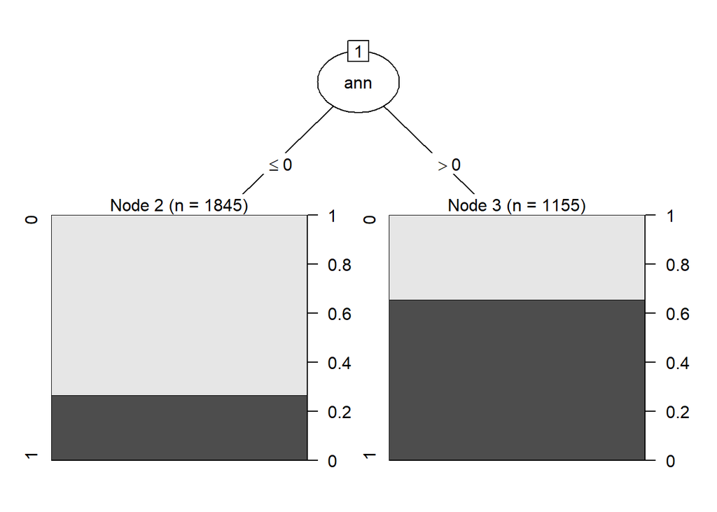

```r
# Create Predictions Dataframe combining all model results
combined<-data.frame(ann=as.numeric(as.character(predicted_sal2)),knn=as.numeric(as.character(dssal_knn_test_pred1)),log=as.numeric(as.character(binresults)),dt=as.numeric(as.character(dssal_DT_predict)), actual=dssalariestest_norm$salaryabove)

# Separate data to train and test
combined_test <- combined[1:1000,]
combined_train <- combined[1001:4000,]

# Create stacked model
stacked<-C5.0(actual~. ,data=combined_train)
plot(stacked)
```

```r
summary(stacked)
```

```
##
## Call:
## C5.0.formula(formula = actual ~ ., data = combined_train)
##
##
## C5.0 [Release 2.07 GPL Edition]      Sun Apr 25 16:26:04 2021
## -------------------------------
##
## Class specified by attribute `outcome'
##
## Read 3000 cases (5 attributes) from undefined.data
##
## Decision tree:
##
## ann <= 0: 0 (1845/491)
## ann > 0: 1 (1155/400)
##
##
## Evaluation on training data (3000 cases):
##
##      Decision Tree
##    ----------------
##    Size      Errors
##
##       2  891(29.7%)   <<
##
##
##     (a)   (b)    <-classified as
##    ----  ----
##    1354   400    (a): class 0
##     491   755    (b): class 1
##
##
##  Attribute usage:
##
##  100.00% ann
##
##
## Time: 0.0 secs
```

```r
# Stacked model prediction
final_predict <- predict(stacked, combined_test)

#Stacked model results Confusion Matrix
stackedresults <- confusionMatrix(as.factor(final_predict),as.factor(combined_test$actual),positive = "1")
stackedresults
```

```
## Confusion Matrix and Statistics
##
##           Reference
## Prediction   0   1
##          0 462 181
##          1 125 232
##
##                Accuracy : 0.694
##                  95% CI : (0.6644, 0.7225)
##     No Information Rate : 0.587
##     P-Value [Acc > NIR] : 1.738e-12
##
##                   Kappa : 0.3559
##
##  Mcnemar's Test P-Value : 0.001666
##
##             Sensitivity : 0.5617
##             Specificity : 0.7871
##          Pos Pred Value : 0.6499
##          Neg Pred Value : 0.7185
##              Prevalence : 0.4130
##          Detection Rate : 0.2320
##    Detection Prevalence : 0.3570
##       Balanced Accuracy : 0.6744
##
##        'Positive' Class : 1
##
```

## Tuned Model

```r
# use trainControl() to alter resampling strategy using 10 fold cv
ctrl <- trainControl(method = "cv", number = 10,
                     selectionFunction = "oneSE")

# use expand.grid() to create grid of tuning parameters, varying trials from 1 to 5
grid <- expand.grid(.model = "tree",
                    .trials = c(1, 2, 3, 4, 5),
                    .winnow = "FALSE")

# look at the result of expand.grid()
grid
```

```
##   .model .trials .winnow
## 1   tree       1   FALSE
## 2   tree       2   FALSE
## 3   tree       3   FALSE
## 4   tree       4   FALSE
## 5   tree       5   FALSE
```

```r
# customize train() with the control list and grid of parameters
set.seed(300)
m <- train(actual ~ ., data = combined, method = "C5.0",
           metric = "Kappa",
           trControl = ctrl,
           tuneGrid = grid)
m
```

```
## C5.0
##
## 4000 samples
##    4 predictor
##    2 classes: '0', '1'
##
## No pre-processing
## Resampling: Cross-Validated (10 fold)
## Summary of sample sizes: 3601, 3600, 3600, 3600, 3600, 3600, ...
## Resampling results across tuning parameters:
##
##   trials  Accuracy   Kappa
##   1       0.7022546  0.3666570
##   2       0.7022546  0.3666570
##   3       0.7037534  0.3745039
##   4       0.7050040  0.3709433
##   5       0.7050053  0.3805060
##
## Tuning parameter 'model' was held constant at a value of tree
## Tuning
##  parameter 'winnow' was held constant at a value of FALSE
## Kappa was used to select the optimal model using  the one SE rule.
## The final values used for the model were trials = 3, model = tree and winnow
##  = FALSE.
```

## Discussion

### Analysis scope

Using the data set, “How much does data scientists earn in 2017-2020,” which is the dataset processed from the Stack overflow Annual Developers Survey, we analyzed and predicted how data scientists expect to earn above mean salary among this data set which is $64.75k to provide career planning to *Twerk from Home!* clients (Salary converted to annual USD salaries using the exchange rate on each year, assuming 12 working months and 50 working weeks.).

### Logistic Regression Model results

According to the Logistic Regression Model results, we could find out some crucial factors for a higher salary among data-related jobs. For instance, an education level that is the highest level of formal education that candidates have completed shows interesting insights. The Professional degree (JD, MD, etc., not included MBA) shows a statistically lower probability of gaining above mean salary than the Basic (Master, Bachelor, or lower). In contrast, Doctorate education has a positive impact on their salary. We interpreted this result that a professional degree is not common in the data-related business field yet. High education in different areas is not necessary to lead to higher compensation in data-related jobs. Also, we confirmed that a full-time job offers a significantly higher salary than a part-timer, independent contractor, freelancer, or self-employed data scientist. We can also say that organizations which employ more than 10k show higher salary. Which means that even though job offer from venture company seems attractive due to the challenging opportunity, future skill growth, and right of autonomy, the overall well-established company would offer stable compensation for data-related jobs. One exciting finding is that undergrad majors in Computer science, Information systems, or Web development/web design are not statistically positive factors for a higher salary of data-related jobs. This seems counter to our intuition, but we concluded that data-related skills are required in various business fields. In other words, the person who can mash up a specialty in each field and data-related skills are scarce in job markets, and they gain higher salary than the specialized person only in typical and traditional computer science fields. The dataset has the following four specific career types among data-related jobs.

- Data Scientist or Machine Learning Specialist
- Database Administrator
- Data Analyst
- Business Analyst and Data Engineer

Overall, the logistic regression model using variables with only 0.05 or less significance results in an accuracy of **70.22**% and a kappa of **0.367**.

### KNN Model results

Various K values were tested to determine the best performing KNN model, starting with the square root of the number of rows (119). The best performing model based on kappa was found at k=13. The model results in an accuracy of **67.2**% and a kappa of **0.307**.

### ANN Model results

A simple ANN model with one hidden node was created and results in an accuracy of **70.08**% and a kappa of **0.376**. Various other numbers of hidden nodes were tested and did not result in significantly better results for the added complexity.

### Decision Tree Model results

A decision tree model showed similar variables of importance as the logistic regression model. The variable used in 100% of decisions is the years of professional coding experience showing its significance to determining salary. The following most used variables are part time versus full time employment and the organization size as discussed previously. Job satisfaction also plays an important role being used in 85.79% of decisions. Further investigation could be performed to understand the relationship between job satisfaction and salary, which could be correlated or causal. Again, Hobbyist is only used in 0.56% of decisions, showing its lesser impact. Overall, the decision tree model results in an accuracy of **69.12**% and a kappa of **0.357**.

We also created a decision tree analysis using a cost matrix. We determined that false positives could be detrimental to our clients if we predict and help them plan for making a higher than average salary when it turns out that they will not. Promising higher salaries than will occur could damage the reputation of the organization. False negatives are less relevant as no one would be unhappy to be making more than they anticipated. Assigning a twice as high cost for false positives, the model produces the following results: an accuracy of **65.97**%, a kappa of **0.227**, and a **3.65**% false positive rate (compared to a false positive rate of **13.925**% in the original decision tree model).

At this time, we have determined that false positives do not provide a huge risk to the business or clients, so we have used the original decision tree model in the analysis going forward. However, we recommend looking into this further in the future and adapting the model as needed.

### Stacked Model results

We constructed a second level stacked model. The ANN is the best performing model with an Accuracy of **70.08**% and the highest Kappa of **0.376** among individual models. The second level combined model uses only the ANN model due to its high performing nature. The second level combined model could not improve Accuracy and Kappa which is **69.4**% and a kappa of **0.356**.

### Model Tuning

Finally, we tuned the second level model using 10 cross validation and various trials for decision tree models. Using 10 fold cross validation reduces over-fitting and increases the reliability of the result. The results of all combinations are similar to results of the original ANN algorithm and better than the single stacked model created. This result shows the reliability of the model using various test and train sets despite the initial stacked model being slightly worse. 3 trials with no winnowing gives us the best performing model based on kappa values and oneSE. Higher kappa values are achieved with higher number of trials, but the value gained does not out-weigh the added complexity of the additional trials. Overall, we are confident with the reliability of the model to predict with about 70% accuracy and around 37% better than chance to help guide our clients to improve their data science careers.

We recommend using boosting or random forest techniques to improve the final decision tree analysis even further. We also recommend further exploring Country as a variable, as it will likely lead to significant distinctions as well.

### Recommendation

Based on these results, we concluded that we could utilize this model, especially the ANN model, to predict career success in terms of gaining salary above mean for *Twerk from Home!* clients (which could be in the areas such as career development center in university or a job-changing advisory service). Though Data Scientist or Machine Learning Specialist career seems attractive among data-related jobs, to secure a higher salary, we would advise candidates to broaden their skill sets to business fields or aim for an engineering position in the upstream process and continue to work in the field for many years.

Data source: https://www.kaggle.com/phuchuynguyen/datarelated-developers-survey-by-stack-overflow?select=processed_data_toDummies.csv